# STA 112: Lab 04

Qingyang Liu

2026-10-12

## Introduction

In this lab, you will practice several fundamental skills for working with data in `R`. You will learn how to:

- conduct hypothesis testing for the slope $\beta_1$
- confidence interval for $\beta_1$
- model prediction and associated intervals
- coding of categorical variable

## Penguin Data

Before starting the lab, download `penguins.xlsx` from Canvas and place the file in your R project working directory.

The dataset contains physical measurements and demographic information for 344 penguins observed in the Palmer Archipelago, Antarctica.

### Variable Dictionary

- `species`: Penguin species: Adelie, Chinstrap, or Gentoo
- `island`: Island where the penguin was observed: Biscoe, Dream, or Torgersen
- `bill_length_mm`: Bill length in millimeters
- `bill_depth_mm`: Bill depth in millimeters
- `flipper_length_mm`: Flipper length in millimeters
- `body_mass_g`: Body mass in grams
- `sex`: Penguin sex: female or male
- `year`: Study year: 2007, 2008, or 2009

### Data Source

Data were collected by Palmer Station Antarctica LTER and Dr. Kristen Gorman.

Gorman KB, Williams TD, and Fraser WR (2014). Ecological Sexual Dimorphism and Environmental Variability within a Community of Antarctic Penguins (Genus *Pygoscelis*). *PLoS ONE*, 9(3), e90081.

Repository: Environmental Data Initiative. [doi:10.6073/pasta/98b16d7d563f265cb52372c8ca99e60f](https://doi.org/10.6073/pasta/98b16d7d563f265cb52372c8ca99e60f)

## Exercise 01: Importing and Cleaning Data

Because base `R` does not natively support Excel files, we use the `readxl` package to import `.xlsx` data. Run the code block below to load the necessary packages, import `penguins.xlsx`, and create a cleaned dataset (`df_penguins_cleaned`) by dropping all rows containing missing values.

```r
library(readxl)
library(tidyverse)
```

```r
df_penguins <- read_xlsx("penguins.xlsx")
df_penguins_cleaned <- df_penguins |>
  drop_na()
```

## Exercise 02: Filtering for Male Gentoo Penguins (5 Points)

Using the `df_penguins_cleaned` dataset, create a new subset named `df_male_gentoo` that contains only **male Gentoo** penguins.

*Hint: Use the `filter()` function from `tidyverse` to subset rows based on both the `species` and `sex` variables.*

```r
# type your codes here
```

- What are the dimensions of `df_male_gentoo` (i.e., the number of observations and variables)? (5 Points)

Answer:

- **Sanity Check**: *Before moving on to the next exercises, run the code below to verify your filtered dataset:*

```
mean(df_male_gentoo$flipper_length_mm)
```

You should get `221.541`. **If your output is different, double-check your filtering conditions in Exercise 01 and 02 before proceeding!**

## Exercise 03: Visualizing the Relationship Between Flipper Length and Body Mass (5 Points)

Before fitting a linear model, it is essential to explore the relationship between your variables visually. Using `ggplot2` and your `df_male_gentoo` dataset, construct a scatter plot to visualize body mass ($y$) versus flipper length ($x$).

Your scatter plot should meet the following requirements:

- X-axis: Flipper length in millimeters (`flipper_length_mm`) with a clear label.
- Y-axis: Body mass in grams (`body_mass_g`) with a clear label.
- Title: An informative figure title.

```r
# Type your codes here
```

## Exercise 04: Hypothesis Testing for the Slope (40 Points)

In this exercise, you will investigate whether there is a statistically significant linear relationship between flipper length and body mass for male Gentoo penguins using simple linear regression.

1. Model Fitting & Summary (5 Points)

Fit a simple linear regression model with `body_mass_g` as the response variable ($y$) and `flipper_length_mm` as the predictor variable ($x$). Save the fitted model object as `slr_male_gentoo` and print its `summary()`.

```r
# Type your codes here
```

2. State the Hypotheses (5 Points)

State the null ($H_0$) and alternative ($H_a$) hypotheses for testing whether flipper length is a significant linear predictor of body mass.

*Hint: Write your hypotheses using LaTeX math syntax. In R Markdown, inline math is written between dollar signs $ … $ (e.g., $H_0: \beta_1 = 0$).*

Answer:

3. Based on the `summary()` output, report the calculated $t$-statistic and the corresponding $p$-value for the slope coefficient ($\beta_1$). (5 Points)

Answer:

4. Verify the $t$-Test $p$-Value (5 Points)

Use the `pt()` function to manually compute the two-tailed $p$-value for the $t$-test associated with $\beta_1$, and round your answer to 4 decimal places.

```r
# Type your codes here
```

5. ANOVA Table (5 Points)

Generate the Analysis of Variance (ANOVA) table for the fitted model using the `anova()` function.

```r
# Type your codes here
```

6. $F$-Test Results (5 Points)

Based on the ANOVA table, report the calculated $F$-statistic and its corresponding $p$-value.

Answer:

7. Verify the $F$-Test $p$-Value (5 Points)

Use the `pf()` function to manually compute the $p$-value for the $F$-test, and round your answer to 4 decimal places.

```r
# Type your codes here
```

8. Decision & Conclusion (5 Points)

At the $\alpha = 0.05$ significance level, state your statistical decision (reject or fail to reject $H_0$) and provide a conclusion in the context of the problem.

Answer:

## Exercise 05: Confidence Intervals and Prediction Intervals (20 Points)

In this exercise, you will construct and interpret confidence intervals for the slope parameter $\beta_1$, as well as interval estimates for predictions when `flipper_length_mm = 210`.

1. Confidence Interval for $\beta_1$ Using `confint()` (5 Points)
1. Use the `confint()` function to compute the 95% confidence interval for the slope parameter $\beta_1$. (2.5 Points)

```r
# Type your codes here
```

2. Interpret the 95% confidence interval in the context of the problem. (2.5 Points)

Answer:

2. Calculate the 95% Confidence Interval of $\beta_1$ by Finding Critical Value (5 Points)

Using the formula $\hat{\beta}_1 \pm t^* \cdot SE(\hat{\beta}_1)$, manually calculate the 95% confidence interval for the slope. Use qt() to find the critical value $t^*$ with $df = 59$.

```r
# Type your codes here
```

Answer:

- Critical value ($t^*$):
- Calculated 95% CI:
3. Confidence and Prediction Intervals at 210 mm (10 Points)
1. Calculate both the 90% Confidence Interval for the mean response and the 90% Prediction Interval for an individual observation when `flipper_length_mm = 210`. (5 Points)

```r
# Type your codes here
```

2. Interpret both intervals in context and explain why the prediction interval is wider than the confidence interval. (5 Points)

Answer:

- 90% Confidence Interval Interpretation:
- 90% Prediction Interval Interpretation:
- Comparison:

## Exercise 06: Categorical Predictor (30 Points)

1. Create a subset containing only Gentoo penguins (`df_gentoo`) from `df_penguins_cleaned`. (5 Points)

```r
# Type your codes here
```

2. Fit Simple Linear Regression (5 Points)

Fit a simple linear regression model predicting body mass (`body_mass_g`) using sex (`sex`) as the predictor, and display the summary statistics:

```r
# Type your codes here
```

3. Regression Equation & Reference Group (5 Points)
- Write down the estimated regression equation based on your model output. (2.5 Points)

Answer:
$$\widehat{\text{body mass}} = ??
+ ?? \cdot \mathbb{1}_\text{male}$$
(where $\mathbb{1}_\text{male} = 1$ for male penguins and $0$ for female penguins)

- Identify the reference (baseline) group for the categorical variable `sex`. (2.5 Points)

Answer:

4. Interpret the Coefficients (5 Points)

   Provide a clear, in-context interpretation of the following quantities from your model:
   1. $\hat{\beta}_0$ (the intercept)
   2. $\hat{\beta}_0 + \hat{\beta}_{\text{sexmale}}$

Answer:

5. Calculate the sample mean body mass for each sex using `group_by()` and `summarise()` (5 Points)

Answer:

```r
# Type your codes here
```

6. Compare the calculated group means with the estimated regression values ($\hat{\beta}_0$ and $\hat{\beta}_0 + \hat{\beta}_{\text{sexmale}}$). Report your findings and explain what this relationship reveals about regression models with a single binary predictor. (5 Points)

Answer:

## Tutorial: Visualization of the Prediction Interval and Confidence Interval

### Step 1: Create a Grid of New Predictor Values

Generate a new data frame, `data_new`, containing a fine grid of 100 evenly spaced `flipper_length_mm` values across the range of observed values in `df_male_gentoo`.

```r
df_male_gentoo <- df_penguins_cleaned |>
  filter(species == "Gentoo",
         sex == "male")

# 1. Create a sequence of flipper lengths for evaluation
data_new <- data.frame(
  flipper_length_mm = seq(
    from = min(df_male_gentoo$flipper_length_mm),
    to   = max(df_male_gentoo$flipper_length_mm),
    length.out = 100
  )
)
```

### Step 2: Compute 90% Confidence and Prediction Intervals

Use `predict()` to generate the fitted values (`fit`) along with the lower (`lwr`) and upper (`upr`) bounds for both intervals at a $90\%$ level (`level = 0.90)`.

- Confidence Interval (CI): Captures the uncertainty around the estimated mean response.
- Prediction Interval (PI): Captures the uncertainty for an individual new observation (incorporating residual variance).

```r
slr_male_gentoo <- lm(body_mass_g ~ flipper_length_mm, data = df_male_gentoo)

df_CI <- as.data.frame(
  predict(slr_male_gentoo,
          newdata = data_new,
          level = 0.90,
          interval = "confidence")
)
df_PI <- as.data.frame(
  predict(slr_male_gentoo,
          newdata = data_new,
          level = 0.90,
          interval = "prediction")
)
```

### Step 3: Prepare the Data for Plotting

Attach the predictor values (`flipper_length_mm`) and an identifying label (`method`) to each data frame, then stack them into a single data frame (`df_plot`).

```r
df_CI$flipper_length_mm <- data_new$flipper_length_mm
df_CI$method <- "CI"

df_PI$flipper_length_mm <- data_new$flipper_length_mm
df_PI$method <- "PI"

# Combine into a single plotting data frame
df_plot <- rbind(df_CI, df_PI)
```

### Step 4: Plot Data, Regression Line, and Interval Bounds

Overlay the original sample data, the fitted linear regression line, and the upper/lower bounds for both the confidence and prediction intervals using `ggplot()`.

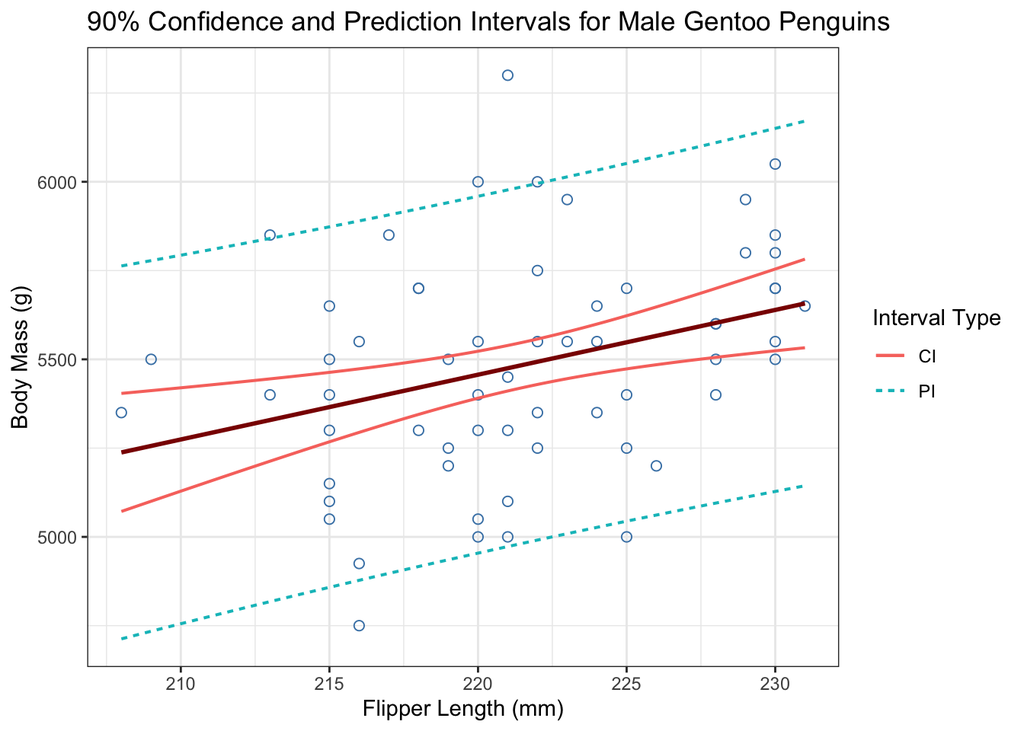

```r
ggplot() +
  # Original data points
  geom_point(
    data = df_male_gentoo,
    aes(x = flipper_length_mm, y = body_mass_g),
    color = "steelblue",
    shape = 1,
    size = 2
  ) +
  # Upper and lower interval bounds (linewidth placed OUTSIDE aes)
  geom_line(
    data = df_plot,
    aes(x = flipper_length_mm, y = lwr, linetype = method, color = method),
    linewidth = 0.7
  ) +
  geom_line(
    data = df_plot,
    aes(x = flipper_length_mm, y = upr, linetype = method, color = method),
    linewidth = 0.7
  ) +
  # Fitted regression line
  geom_line(
    data = df_CI,
    aes(x = flipper_length_mm, y = fit),
    color = "darkred",
    linewidth = 1
  ) +
  labs(
    x = "Flipper Length (mm)",
    y = "Body Mass (g)",
    title = "90% Confidence and Prediction Intervals for Male Gentoo Penguins",
    color = "Interval Type",
    linetype = "Interval Type"
  ) +
  theme_bw()
```